# Los Angeles Crime Statistics

2024-04-30

## R Markdown

**Zane, Cameron, Josh, Nicholas, Niraj**

## Data Information

For our project, we retrieved a data set from https://catalog.data.gov/dataset/crime-data-from-2020-to-present.

This data set reflects incidents of crime in the city of Los Angeles dating back to 2020. There were originally over 918,000 rows, which we have brought down to 200,000 to make it easier to work with. This is still a very large data set.

```r
library(dplyr)
crimes <- read.csv("https://raw.githubusercontent.com/ZaneE5/ds202finalproject/main/crimes.csv")

crimes %>% head()
```

```
##       DR_NO       Date.Rptd       DATE.OCC TIME.OCC AREA AREA.NAME Rpt.Dist.No
## 1 190326475   3/1/2020 0:00  3/1/2020 0:00     2130    7  Wilshire         784
## 2 200106753   2/9/2020 0:00  2/8/2020 0:00     1800    1   Central         182
## 3 200320258 11/11/2020 0:00 11/4/2020 0:00     1700    3 Southwest         356
## 4 200907217  5/10/2023 0:00 3/10/2020 0:00     2037    9  Van Nuys         964
## 5 220614831  8/18/2022 0:00 8/17/2020 0:00     1200    6 Hollywood         666
## 6 231808869   4/4/2023 0:00 12/1/2020 0:00     2300   18 Southeast        1826
##   Part.1.2 Crm.Cd                              Crm.Cd.Desc             Mocodes
## 1        1    510                         VEHICLE - STOLEN
## 2        1    330                    BURGLARY FROM VEHICLE      1822 1402 0344
## 3        1    480                            BIKE - STOLEN           0344 1251
## 4        1    343 SHOPLIFTING-GRAND THEFT ($950.01 & OVER)           0325 1501
## 5        2    354                        THEFT OF IDENTITY 1822 1501 0930 2004
## 6        2    354                        THEFT OF IDENTITY 1822 0100 0930 0929
##   Vict.Age Vict.Sex Vict.Descent Premis.Cd
```

[output cut: 27 more lines]

A description of the dataset and each column can be found at https://data.lacity.org/Public-Safety/Crime-Data-from-2020-to-Present/2nrs-mtv8/about_data. The variables in the dataset are as follows:

- **DR_NO**: Division of Records Number: Official file number made up of a 2 digit year, area ID, and 5 digits. This variable has type int.
- **Date.Rptd**: The date the crime was reported, of type character.
- **DATE.OCC**: The date the crime occurred, of type character.
- **TIME.OCC**: The time the crime occurred, in 24h military time, of type int.
- **AREA**: The LAPD has 21 Community Police Stations referred to as Geographic Areas within the department. These Geographic Areas are sequentially numbered from 1-21. This variable is of type int.
- **AREA.NAME**: The 21 Geographic Areas or Patrol Divisions are also given a name designation that references a landmark or the surrounding community that it is responsible for. Of type chr.
- **Rpt.Dist.No**: A four-digit code that represents a sub-area within a Geographic Area. All crime records reference the “RD” that is occurred in for statistical comparisons. Of type int.
- **Part.1.2**: Unknown. Of type int.
- **Crm.Cd**: Indicates the crime committed, of type int. (Same as Crime Code 1)
- **Crm.Cd.Desc**: Defines the crime code provided, of type chr.
- **Mocodes**: Modus Operandi: Activites associated with the suspect in commission of the crime. Unknown what these mean. Of type chr.
- **Vict.Age**: The age of the victim, of type int.
- **Vict.Sex**: The sex of the victim, of type chr. X means unknown.
- **Vict.Descent**: The descent of the victim, of type chr: A - Other Asian B - Black C - Chinese D - Cambodian F - Filipino G - Guamanian H - Hispanic/Latin/Mexican I - American Indian/Alaskan Native J - Japanese K - Korean L - Laotian O - Other P - Pacific Islander S - Samoan U - Hawaiian V - Vietnamese W - White X - Unknown Z - Asian Indian
- **Premis.Cd**: The type of structure, vehicle, or location where the crime took place, of type int.
- **Premis.Desc**: Defines the premise code, of type chr.
- **Weapon.Used.Cd**: The type of weapon used in the crime, of type int.
- **Weapon.Desc**: Defines the weapon code provided, of type chr.
- **Status**: Status of the case (IC is the default), of type chr.
- **Status.Desc**: Defines the status code provided, of type chr.
- **Crm.Cd.1/2/3/4**: Indicates the crime committed, of type int. Crime Code 1 is the primary and most serious one. Crime Code 2, 3, and 4 are respectively less serious offenses. Lower crime class numbers are more serious.
- **LOCATION**: Street address of crime incident rounded to the nearest hundred block to maintain anonymity, of type chr.
- **Cross.Street**: Cross street of rounded address, of type chr.
- **LAT**: Latitude, of type num.
- **LON**: Longitude, of type num.

## Our questions:

- What is the most likely victim demographic based on crime committed? - Zane
- What kinds of weapons are used the most and in what crimes? - Joshua
- What is the relationship between type of crime and status of crime (closed or open)? - Niraj
- What is the relationship between the demographic columns in the dataset? - Nicholas

## Data Cleaning

To clean the data, we will remove unecessary columns, fix/remove the data that is incomplete/missing, and format the columns to make them easier to work with.

```r
#data cleaning steps here

#We do not need DR_NO, Part.1.2, Premis.Cd, Weapon.Used.Cd, Mocodes, Crm.Cd, Crm.Cd.1-4, Date.Rptd, DATE.OCC, TIME.OCC, AREA, AREA.NAME, Rpt.Dist.No, Crm.cd, Premis.Desc, LOCATION, Cross.Street, LAT, or LON

crimes <- select(crimes, c("Crm.Cd.Desc", "Vict.Age", "Vict.Sex", "Vict.Descent", "Weapon.Desc", "Status"))

#We change some of the chr columns into factors for ease of grouping later
crimes$Crm.Cd.Desc <- factor(crimes$Crm.Cd.Desc, unique(crimes[,'Crm.Cd.Desc']))
crimes$Vict.Sex <- factor(crimes$Vict.Sex, unique(crimes[,'Vict.Sex']))
crimes$Vict.Descent <- factor(crimes$Vict.Descent, unique(crimes[,'Vict.Descent']))
crimes$Weapon.Desc <- factor(crimes$Weapon.Desc, unique(crimes[,'Weapon.Desc']))
crimes$Status <- factor(crimes$Status, unique(crimes[,'Status']))

#We are keeping the most common crimes and deleting the less common ones, this will make the data easier to work with
toKeep <- tail(crimes %>% group_by(`Crm.Cd.Desc`) %>% count() %>% arrange(`n`),20)
crimes <- filter(crimes, `Crm.Cd.Desc` %in% toKeep$Crm.Cd.Desc)
toKeep
```

```
## # A tibble: 20 × 2
## # Groups:   Crm.Cd.Desc [20]
##    Crm.Cd.Desc                                                  n
##    <fct>                                                    <int>
##  1 VIOLATION OF RESTRAINING ORDER                            2613
##  2 TRESPASSING                                               2857
##  3 INTIMATE PARTNER - AGGRAVATED ASSAULT                     2910
##  4 BRANDISH WEAPON                                           3093
##  5 SHOPLIFTING - PETTY THEFT ($950 & UNDER)                  3551
##  6 CRIMINAL THREATS - NO WEAPON DISPLAYED                    4210
##  7 THEFT FROM MOTOR VEHICLE - GRAND ($950.01 AND OVER)       4800
##  8 THEFT-GRAND ($950.01 & OVER)EXCPT,GUNS,FOWL,LIVESTK,PROD  5528
##  9 ROBBERY                                                   6916
## 10 VANDALISM - MISDEAMEANOR ($399 OR UNDER)                  6992
## 11 THEFT OF IDENTITY                                         8912
## 12 THEFT FROM MOTOR VEHICLE - PETTY ($950 & UNDER)           9755
## 13 THEFT PLAIN - PETTY ($950 & UNDER)                       10868
## 14 INTIMATE PARTNER - SIMPLE ASSAULT                        10868
## 15 ASSAULT WITH DEADLY WEAPON, AGGRAVATED ASSAULT           11542
## 16 BURGLARY FROM VEHICLE                                    12730
## 17 BURGLARY                                                 12859
## 18 VANDALISM - FELONY ($400 & OVER, ALL CHURCH VANDALISMS)  12948
## 19 BATTERY - SIMPLE ASSAULT                                 16354
## 20 VEHICLE - STOLEN                                         20827
```

After cleaning, we want to get some of the basic information about the dataset.

```r
#marginal summaries
dim(crimes)
```

```
## [1] 171133      6
```

```r
str(crimes)
```

```
## 'data.frame':    171133 obs. of  6 variables:
##  $ Crm.Cd.Desc : Factor w/ 129 levels "VEHICLE - STOLEN",..: 1 2 5 5 5 5 5 6 5 1 ...
##  $ Vict.Age    : int  0 47 28 41 25 27 24 26 26 0 ...
##  $ Vict.Sex    : Factor w/ 5 levels "M","X","F","",..: 1 1 1 1 1 3 3 1 1 4 ...
##  $ Vict.Descent: Factor w/ 20 levels "O","X","H","B",..: 1 1 3 3 3 4 4 3 4 6 ...
##  $ Weapon.Desc : Factor w/ 78 levels "","STRONG-ARM (HANDS, FIST, FEET OR BODILY FORCE)",..: 1 1 1 1 1 1 1 2 1 1 ...
##  $ Status      : Factor w/ 5 levels "AA","IC","JA",..: 1 2 2 2 2 2 2 2 2 2 ...
```

```r
head(crimes)
```

```
##             Crm.Cd.Desc Vict.Age Vict.Sex Vict.Descent Weapon.Desc Status
## 1      VEHICLE - STOLEN        0        M            O                 AA
## 2 BURGLARY FROM VEHICLE       47        M            O                 IC
## 3     THEFT OF IDENTITY       28        M            H                 IC
## 4     THEFT OF IDENTITY       41        M            H                 IC
## 5     THEFT OF IDENTITY       25        M            H                 IC
## 6     THEFT OF IDENTITY       27        F            B                 IC
```

## Relationship between Demographic and Crime

We want to find out what the most likely victim demographic is based on crime committed. To do this, I plan to first make a new dataset of only the relevant columns.

```r
demo <- select(crimes, c("Crm.Cd.Desc", "Vict.Age", "Vict.Sex", "Vict.Descent"))

head(demo)
```

```
##             Crm.Cd.Desc Vict.Age Vict.Sex Vict.Descent
## 1      VEHICLE - STOLEN        0        M            O
## 2 BURGLARY FROM VEHICLE       47        M            O
## 3     THEFT OF IDENTITY       28        M            H
## 4     THEFT OF IDENTITY       41        M            H
## 5     THEFT OF IDENTITY       25        M            H
## 6     THEFT OF IDENTITY       27        F            B
```

Next, we use the new dataset to compare the relationship between victim sex and type of crime committed.

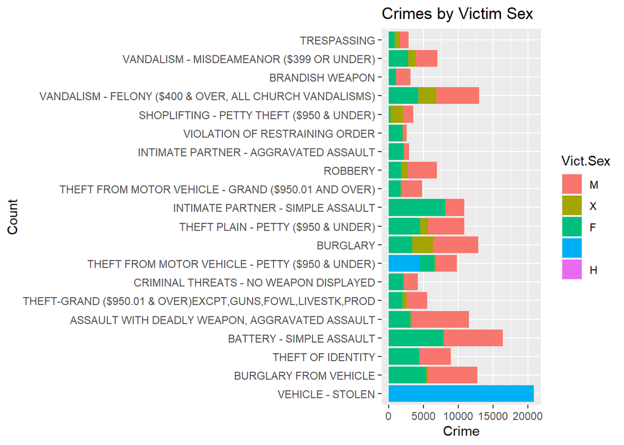

```r
library(ggplot2)

ggplot(demo, aes(x = Crm.Cd.Desc, fill = Vict.Sex)) +
  geom_bar() +
  coord_flip() +
  labs(title = "Crimes by Victim Sex",
         x = "Count",
         y = "Crime")
```

We can see in the chart that there is one obvious outlier. The VEHICLE - STOLEN crime, while the most common, is comprised almost entirely of blank values for Vict.Sex. One potential reason for this could be anonymous calls, but it is unlikely to have an effect of this magnitude. Let’s filter our dataset to exclude the crimes which have no Vict.Sex values, likely representing a forgotten value when filling out forms and thus an incomplete record.

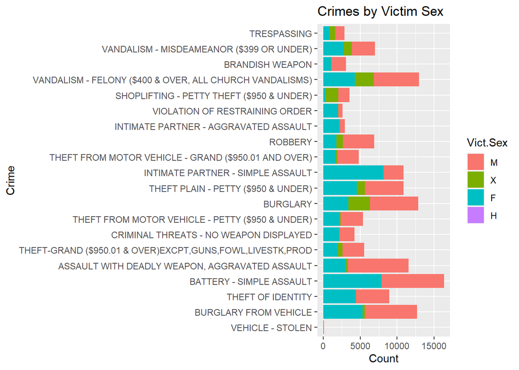

```r
demo <- demo %>% filter(Vict.Sex != "")

ggplot(demo, aes(x = Crm.Cd.Desc, fill = Vict.Sex)) +
  geom_bar() +
  coord_flip() +
  labs(title = "Crimes by Victim Sex",
         x = "Crime",
         y = "Count")
```

That looks better. Men are more likely to be victims of weapon brandishing, robbery, grand theft from auto, and assault with deadly weapons/aggravated assault. Women are more likely to be victims of restraining order violations, and intimate partner aggravated and simple assault. The rest of the crimes are fairly even. Many of the robbery-esque crimes have a significant portion of unknown victims, which I could only assume would result from discovery of stolen goods upon an unrelated arrest. In only 14 cases, the victims sex is listed as “H”, which I infer means intersex.

Next, lets compare the relationship between victim descent and type of crime committed.

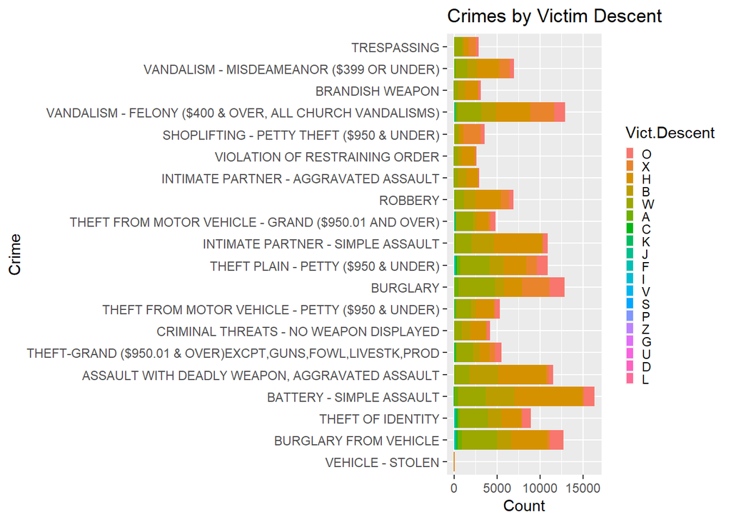

```r
demo <- demo %>% filter(Vict.Descent != "")

ggplot(demo, aes(x = Crm.Cd.Desc, fill = Vict.Descent)) +
  geom_bar() +
  coord_flip() +
  theme(
    legend.key.size = unit(0.2, "cm")
  ) +
  labs(title = "Crimes by Victim Descent",
         x = "Crime",
         y = "Count")
```

The most common victim of each crime is the following:

```r
demo %>% group_by(`Crm.Cd.Desc`) %>%
  count(`Vict.Descent`) %>% arrange() %>% filter(`n` == max(`n`))
```

```
## # A tibble: 20 × 3
## # Groups:   Crm.Cd.Desc [20]
##    Crm.Cd.Desc                                              Vict.Descent     n
##    <fct>                                                    <fct>        <int>
##  1 VEHICLE - STOLEN                                         H               32
##  2 BURGLARY FROM VEHICLE                                    H             4189
##  3 THEFT OF IDENTITY                                        W             3311
##  4 BATTERY - SIMPLE ASSAULT                                 H             7855
##  5 ASSAULT WITH DEADLY WEAPON, AGGRAVATED ASSAULT           H             5556
##  6 THEFT-GRAND ($950.01 & OVER)EXCPT,GUNS,FOWL,LIVESTK,PROD W             1890
##  7 CRIMINAL THREATS - NO WEAPON DISPLAYED                   H             1847
##  8 THEFT FROM MOTOR VEHICLE - PETTY ($950 & UNDER)          H             2075
##  9 BURGLARY                                                 W             4223
## 10 THEFT PLAIN - PETTY ($950 & UNDER)                       W             3416
## 11 INTIMATE PARTNER - SIMPLE ASSAULT                        H             5635
## 12 THEFT FROM MOTOR VEHICLE - GRAND ($950.01 AND OVER)      W             1915
## 13 ROBBERY                                                  H             2987
## 14 INTIMATE PARTNER - AGGRAVATED ASSAULT                    H             1296
## 15 VIOLATION OF RESTRAINING ORDER                           H             1548
## 16 SHOPLIFTING - PETTY THEFT ($950 & UNDER)                 X             2010
## 17 VANDALISM - FELONY ($400 & OVER, ALL CHURCH VANDALISMS)  H             3967
## 18 BRANDISH WEAPON                                          H             1528
## 19 VANDALISM - MISDEAMEANOR ($399 OR UNDER)                 H             2611
## 20 TRESPASSING                                              W              889
```

The large percentages of Hispanic victims seen in the chart and in the table can be explained by the large Hispanic population of Los Angeles.

Next, we compare the relationship between victim age and type of crime committed.

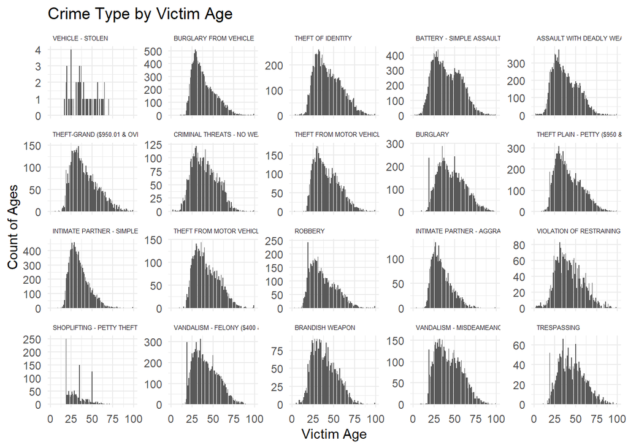

```r
demo <- demo %>% filter(Vict.Age > 0)

ggplot(demo, aes(x = Vict.Age)) +
  geom_bar() +
  facet_wrap(~ Crm.Cd.Desc, scales = "free_y") +
  labs(title = "Crime Type by Victim Age",
       x = "Victim Age",
       y = "Count of Ages") +
  theme_minimal() +
  theme(strip.text.x = element_text(hjust = 0, size = 5))
```

Most of these charts are skewed right but display a shockingly wide range of values. Lets look a little bit deeper.

```r
mage <- demo %>% group_by(`Crm.Cd.Desc`) %>% summarise(mean_age = mean(`Vict.Age`), min_age = min(`Vict.Age`), max_age = max(`Vict.Age`)) %>%   arrange(`mean_age`)

mage
```

```
## # A tibble: 20 × 4
##    Crm.Cd.Desc                                          mean_age min_age max_age
##    <fct>                                                   <dbl>   <int>   <int>
##  1 SHOPLIFTING - PETTY THEFT ($950 & UNDER)                 32.7      14      82
##  2 INTIMATE PARTNER - AGGRAVATED ASSAULT                    34.4       4      99
##  3 INTIMATE PARTNER - SIMPLE ASSAULT                        34.8       4      99
##  4 ROBBERY                                                  37.0       3      99
##  5 ASSAULT WITH DEADLY WEAPON, AGGRAVATED ASSAULT           37.8       2      99
##  6 BRANDISH WEAPON                                          38.9       5      99
##  7 BURGLARY FROM VEHICLE                                    39.1      11      99
##  8 VEHICLE - STOLEN                                         39.8      17      70
##  9 CRIMINAL THREATS - NO WEAPON DISPLAYED                   40.2       2      99
## 10 BATTERY - SIMPLE ASSAULT                                 41.0       2      99
## 11 THEFT-GRAND ($950.01 & OVER)EXCPT,GUNS,FOWL,LIVESTK…     41.2       6      99
## 12 THEFT PLAIN - PETTY ($950 & UNDER)                       41.3       8      99
## 13 VANDALISM - FELONY ($400 & OVER, ALL CHURCH VANDALI…     41.5       3      99
## 14 THEFT FROM MOTOR VEHICLE - PETTY ($950 & UNDER)          41.7       3      99
## 15 THEFT FROM MOTOR VEHICLE - GRAND ($950.01 AND OVER)      42.3      10      99
## 16 VIOLATION OF RESTRAINING ORDER                           42.3       2      99
## 17 VANDALISM - MISDEAMEANOR ($399 OR UNDER)                 43.0       9      99
## 18 THEFT OF IDENTITY                                        43.4       4      99
## 19 TRESPASSING                                              45.2      11      99
## 20 BURGLARY                                                 45.8       3      99
```

The minimum and maximum ages are a little bit suspect here. I’m not sure why or how to account for them, but I do know that it is very unlikely that a 10 year old was the victim of grand theft from a motor vehicle. The fact that almost all of them have a maximum victim age of 99 is a little strange, but can be explained at least a little bit by the two digit cap on age in the dataset. Still, it is unlikely that 99+ year old people were the victims of all these crimes, given their low percentage of the population and low mobility.

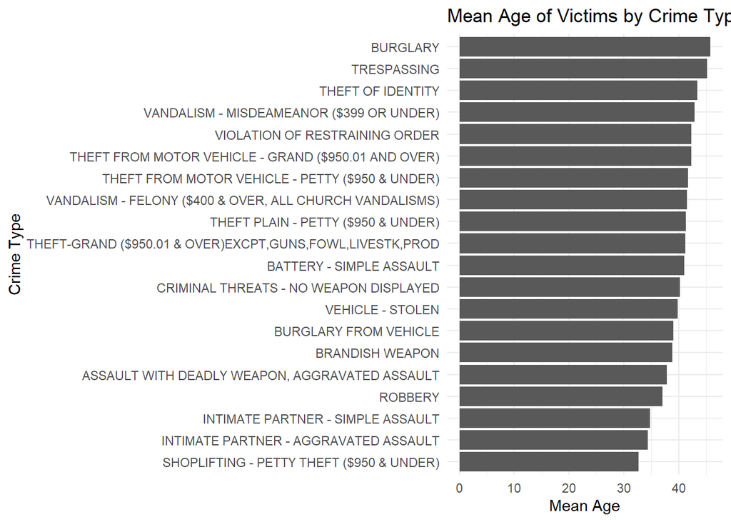

```r
ggplot(mage, aes(x = reorder(Crm.Cd.Desc, mean_age), y = `mean_age`)) +
  geom_bar(stat="identity") +
  coord_flip() +
  labs(title = "Mean Age of Victims by Crime Type",
       x = "Crime Type",
       y = "Mean Age") +
  theme_minimal()
```

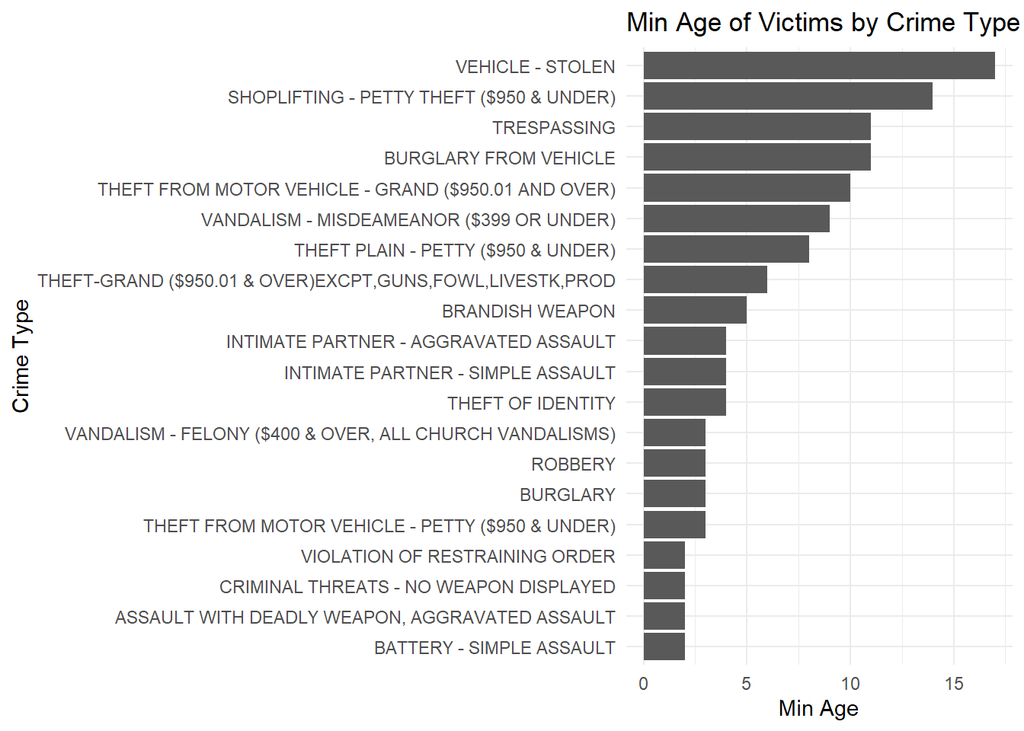

```r
ggplot(mage, aes(x = reorder(Crm.Cd.Desc, min_age), y = `min_age`)) +
  geom_bar(stat="identity") +
  coord_flip() +
  labs(title = "Min Age of Victims by Crime Type",
       x = "Crime Type",
       y = "Min Age") +
  theme_minimal()
```

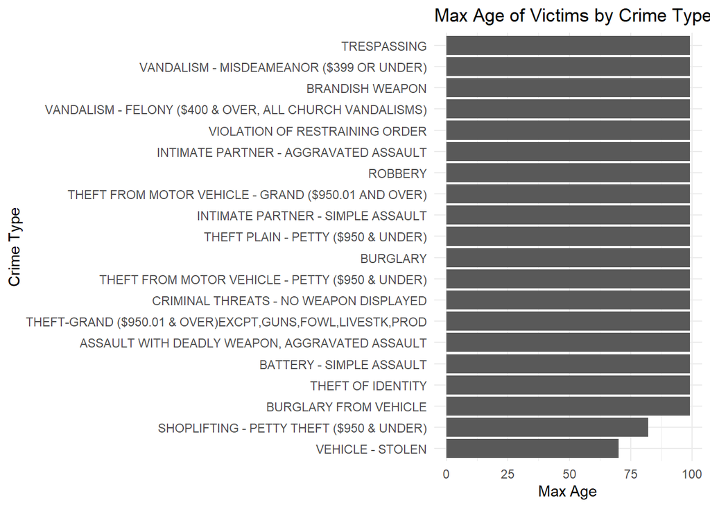

```r
ggplot(mage, aes(x = reorder(Crm.Cd.Desc, max_age), y = `max_age`)) +
  geom_bar(stat="identity") +
  coord_flip() +
  labs(title = "Max Age of Victims by Crime Type",
       x = "Crime Type",
       y = "Max Age") +
  theme_minimal()
```

## Relationship between Crime and Status of Investigation

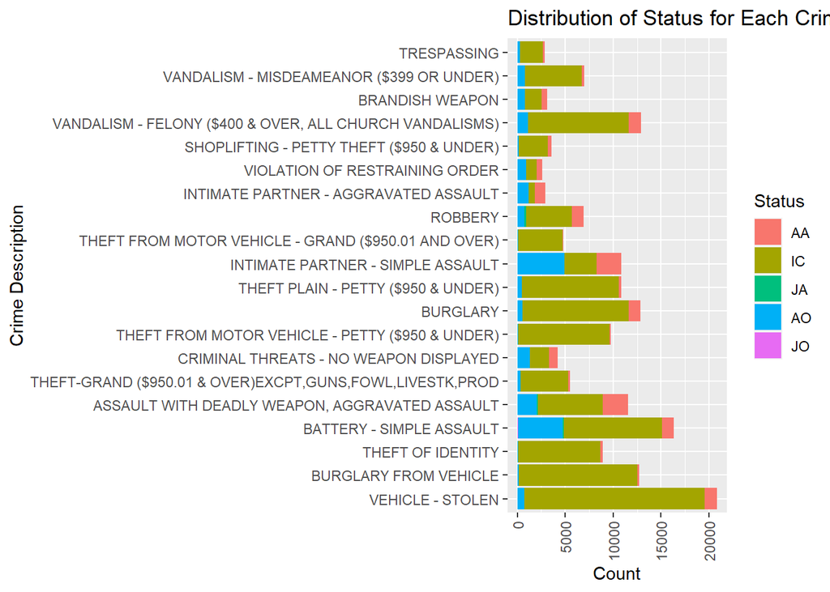

```r
library(ggplot2)

ggplot(crimes, aes(x = `Crm.Cd.Desc`, fill = Status)) +
  geom_bar() +
  labs(
    x = "Crime Description",
    y = "Count",
    title = "Distribution of Status for Each Crime Description"  ) +
  coord_flip()+
  theme(
    axis.text.x = element_text(angle = 90, vjust = 0.5, hjust = 1))
```

## Relationship between Demographics

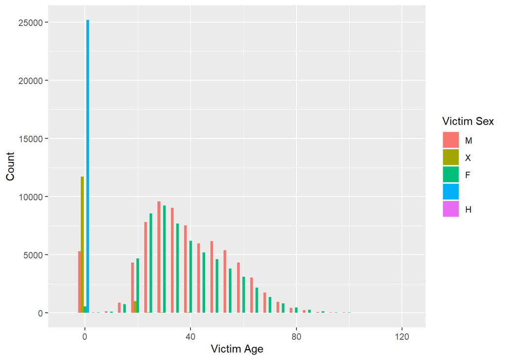

```r
library(ggplot2)
ggplot(crimes, aes(x = `Vict.Age`, fill = `Vict.Sex`)) +
  geom_histogram(binwidth = 5, position = "dodge") +
  labs(x = "Victim Age", y = "Count", fill = "Victim Sex")
```

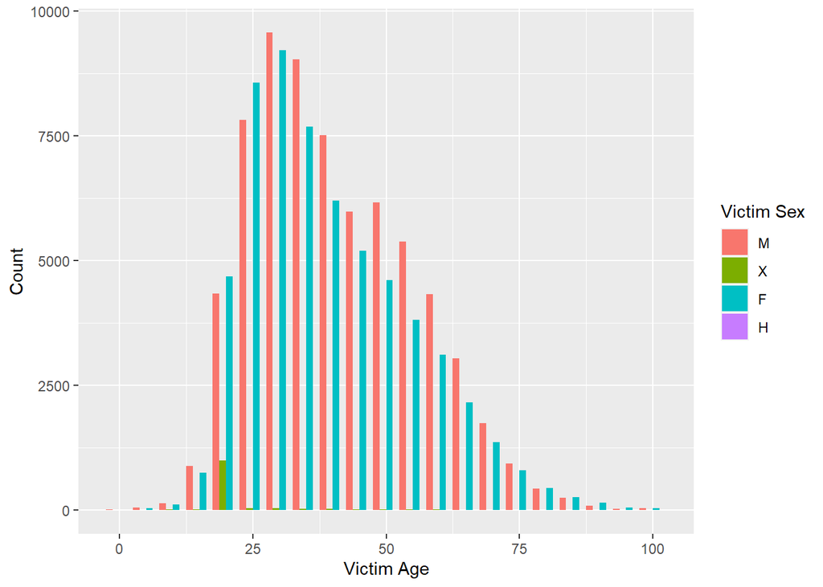

```r
crimesWOempty <- crimes[!is.na(crimes$`Vict.Sex`) & crimes$`Vict.Sex` != "" , ]
crimesWOempty <- crimesWOempty[crimesWOempty$`Vict.Age` > 0, ]

ggplot(crimesWOempty, aes(x = `Vict.Age`, fill = `Vict.Sex`)) +
  geom_histogram(binwidth = 5, position = "dodge") +
  labs(x = "Victim Age", y = "Count", fill = "Victim Sex")
```

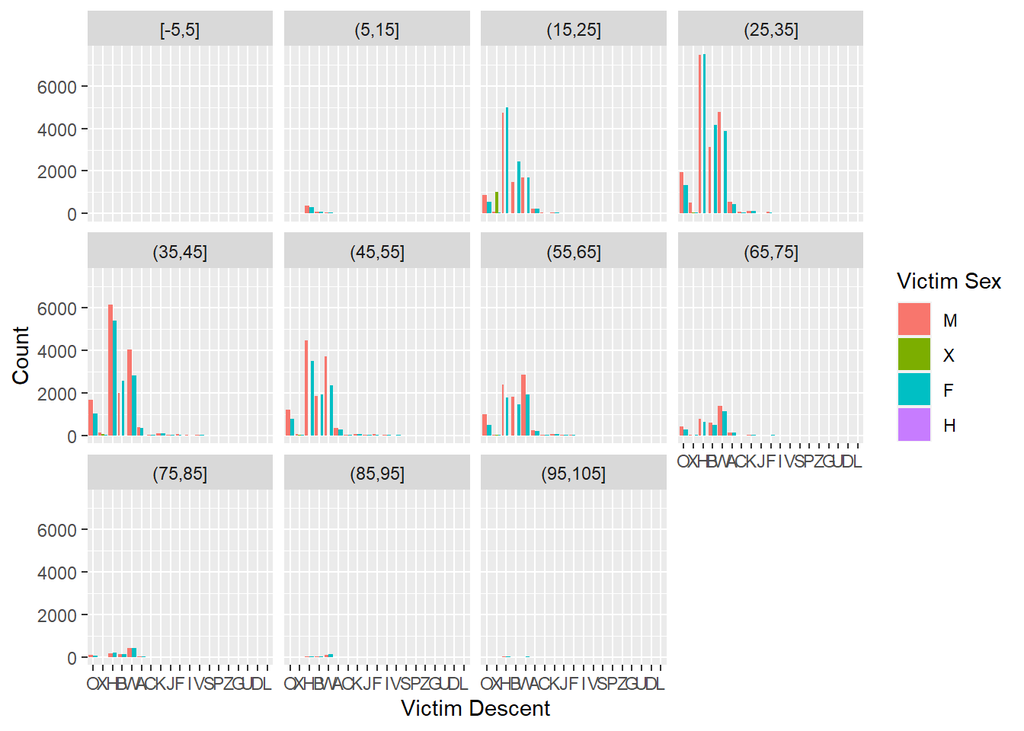

```r
ggplot(crimesWOempty, aes(x = `Vict.Descent`, fill = `Vict.Sex`)) +
  geom_bar(position = "dodge") +
  facet_wrap(~ cut_width(`Vict.Age`, 10)) +
  labs(x = "Victim Descent", y = "Count", fill = "Victim Sex")
```

```r
age_freq <- table(crimesWOempty$`Vict.Age`)
max_age <- names(which.max(age_freq))

cat("The age with the most crime victim is:", max_age, "\n")
```

```
## The age with the most crime victim is: 30
```

```r
median_crimes <- median(age_freq)

median_crimes
```

```
## [1] 867.5
```

```r
high_crime_ages <- names(age_freq[age_freq > median_crimes])
high_crime_ages
```

```
##  [1] "18" "19" "20" "21" "22" "23" "24" "25" "26" "27" "28" "29" "30" "31" "32"
## [16] "33" "34" "35" "36" "37" "38" "39" "40" "41" "42" "43" "44" "45" "46" "47"
## [31] "48" "49" "50" "51" "52" "53" "54" "55" "56" "57" "58" "59" "60" "61" "62"
## [46] "63" "64" "65" "66"
```

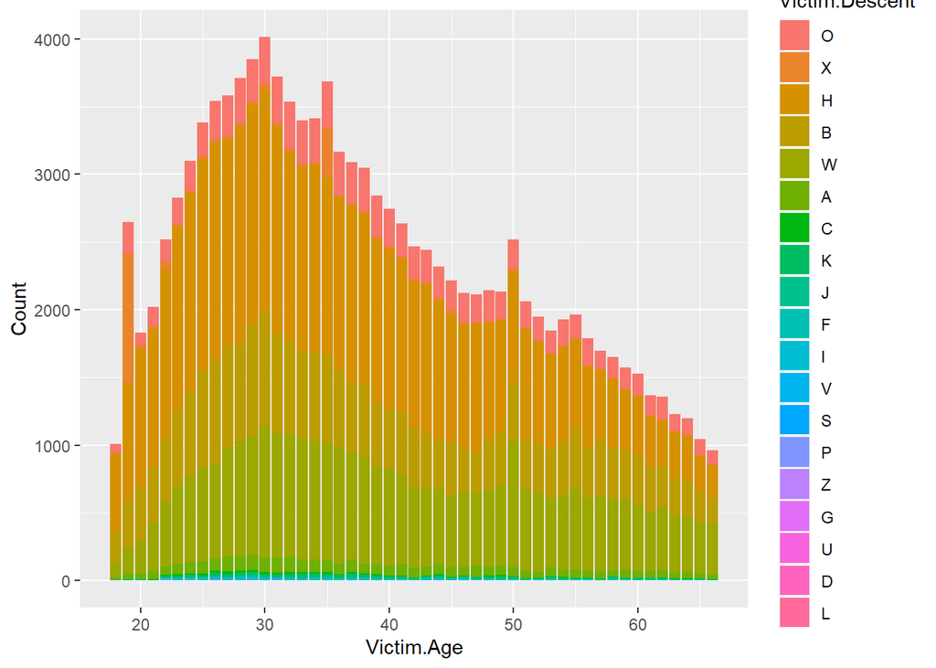

```r
crimesWOempty <- crimesWOempty[crimesWOempty$`Vict.Age` >= 18 & crimesWOempty$`Vict.Age` <= 66 & crimesWOempty$`Vict.Descent` != "", ]
ggplot(crimesWOempty, aes(x = `Vict.Age`, fill = `Vict.Descent`)) +
  geom_histogram(stat = "count") +
  labs(x = "Victim.Age", y = "Count", fill = "Victim.Descent")
```

```r
unique(crimesWOempty$Vict.Descent)
```

```
##  [1] O H B W A C K J F I V S P X Z G U D L
## Levels: O X H B W  A C K J F I V S P Z G U D L
```

```r
unique_descents <- unique(crimes$`Vict.Descent`)
colors <- c("#e41a1c", "#377eb8", "#4daf4a", "#984ea3", "#ff7f00", "#ffff33", "#a65628", "#f781bf", "#999999", "#e7298a", "#66c2a5", "#8da0cb", "#e78ac3", "#fc8d62", "#b3b3b3", "#fdb462", "#bebada", "#fb8072", "#8dd3c7")
```

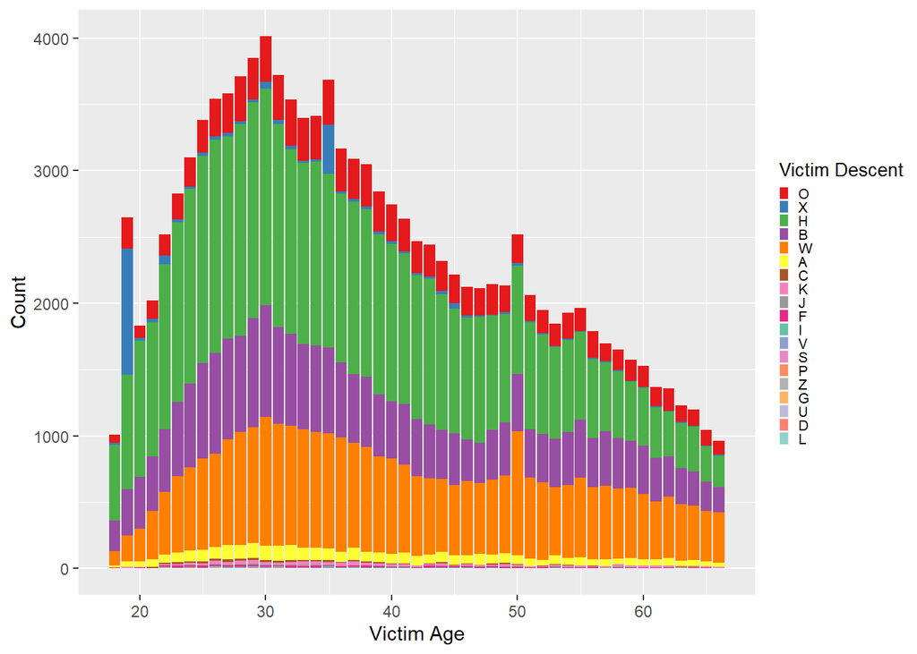

```r
ggplot(crimesWOempty, aes(x = `Vict.Age`, fill = `Vict.Descent`)) +
  geom_histogram(stat = "count") +
  scale_fill_manual(values = colors[1:length(unique_descents)]) +
  labs(x = "Victim Age", y = "Count", fill = "Victim Descent") +
  theme(
    legend.key.size = unit(0.2, "cm"),
    legend.text = element_text(size = 8),
    legend.title = element_text(size = 10),
    legend.spacing = unit(0.1, "cm"),
    legend.margin = margin(t = 2, r = 2, b = 2, l = 2, unit = "pt")
  )
```

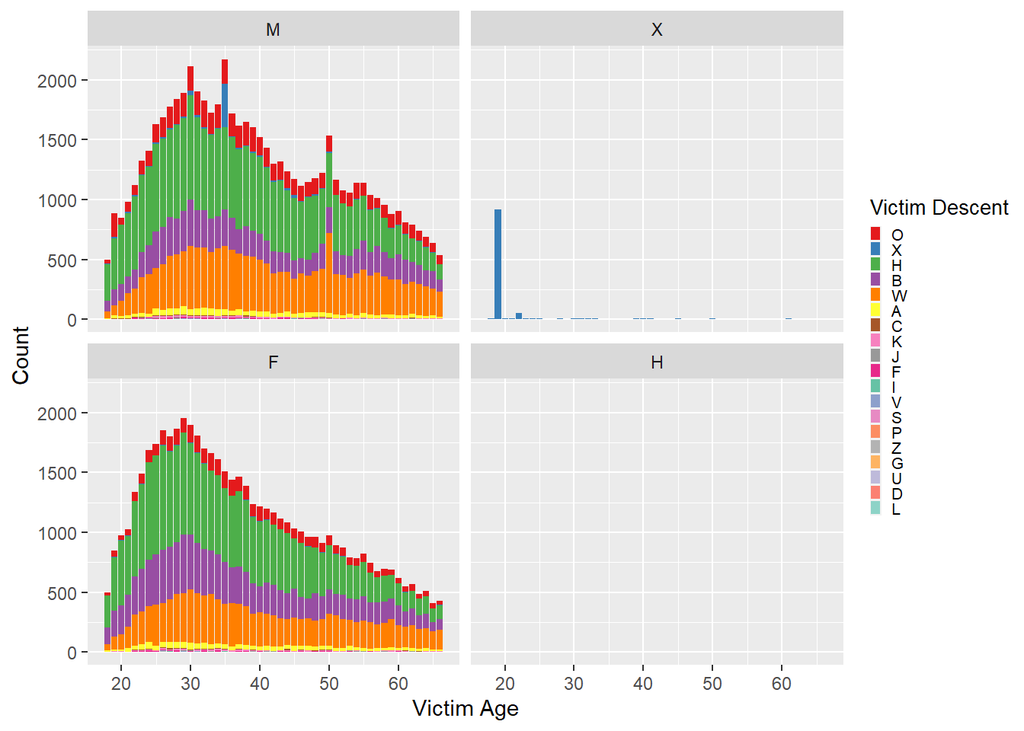

```r
ggplot(crimesWOempty, aes(x = `Vict.Age`, fill = `Vict.Descent`)) +
  geom_histogram(stat = "count") +
  scale_fill_manual(values = colors[1:length(unique_descents)]) +
  labs(x = "Victim Age", y = "Count", fill = "Victim Descent") +
  theme(
    legend.key.size = unit(0.2, "cm"),
    legend.text = element_text(size = 8),
    legend.title = element_text(size = 10),
    legend.spacing = unit(0.1, "cm"),
    legend.margin = margin(t = 2, r = 2, b = 2, l = 2, unit = "pt")
  )+ facet_wrap(~ `Vict.Sex`)
```

## Relationship between Weapon and Crime

Trial and Error: Names were overlapping so I switched the graph to be sideways to make all the labels visible Tried using desc but it automatically followed the grouping. Arrange was easier because it didn’t require me to ungroup. Attempted to do a facet wrap but there were too many variables, even after reducing variables it was difficult to make the graph readable.

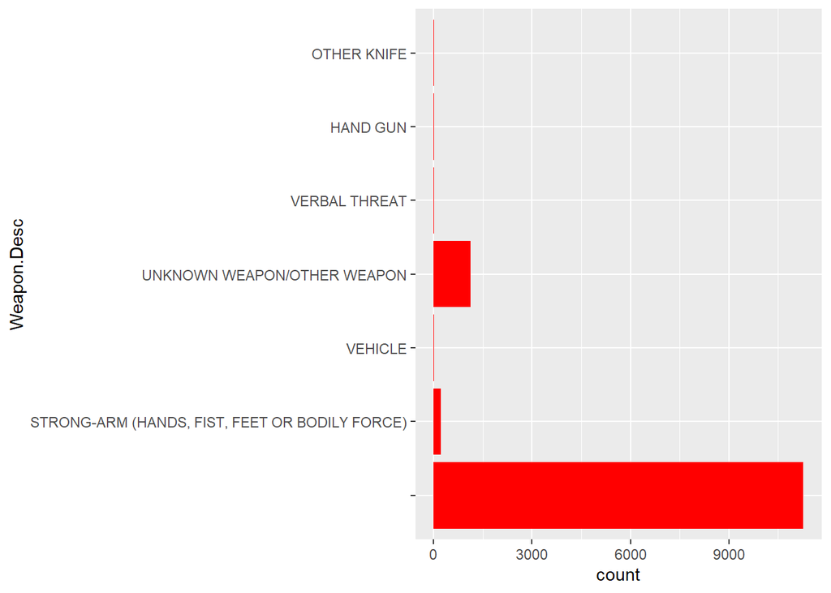

```r
library(ggplot2)
toKeep <- tail(crimes %>% group_by(`Crm.Cd.Desc`) %>% count() %>% arrange(`n`),10)
crimes2 <- filter(crimes, `Crm.Cd.Desc` %in% toKeep$Crm.Cd.Desc)
toKeep <- tail(crimes %>% group_by(`Weapon.Desc`) %>% count() %>% arrange(`n`),10)
crimes3 <- filter(crimes, `Weapon.Desc` %in% toKeep$Weapon.Desc)

filter(crimes3, `Crm.Cd.Desc`=="BURGLARY") %>%
ggplot( aes(y=`Weapon.Desc`)) +
  geom_bar(fill="Red")
```

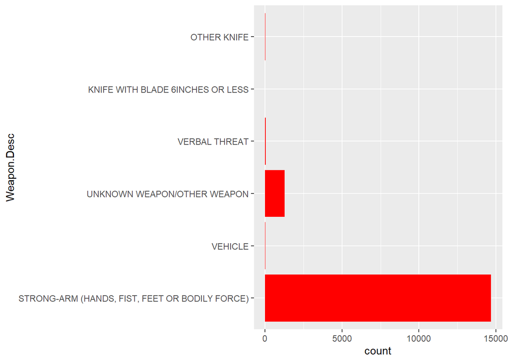

```r
filter(crimes3, `Crm.Cd.Desc`=="BATTERY - SIMPLE ASSAULT") %>%
ggplot( aes(y=`Weapon.Desc`)) +
  geom_bar(fill="Red")
```

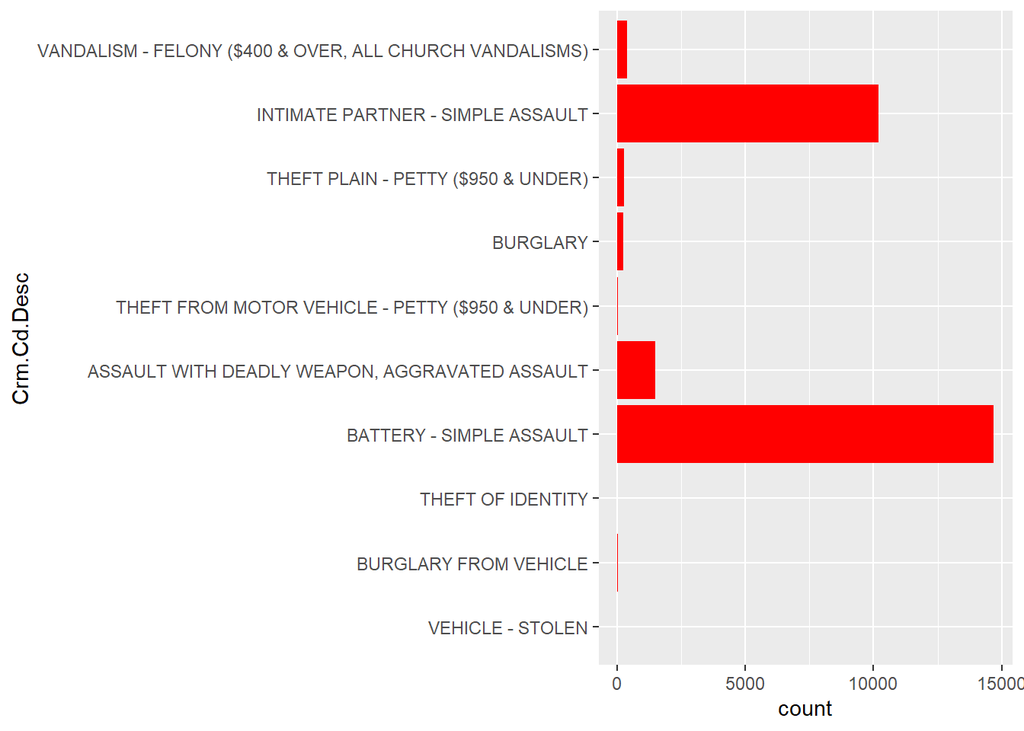

```r
filter(crimes2, `Weapon.Desc`=="STRONG-ARM (HANDS, FIST, FEET OR BODILY FORCE)") %>%
ggplot( aes(y=`Crm.Cd.Desc`)) +
  geom_bar(fill = "Red")
```

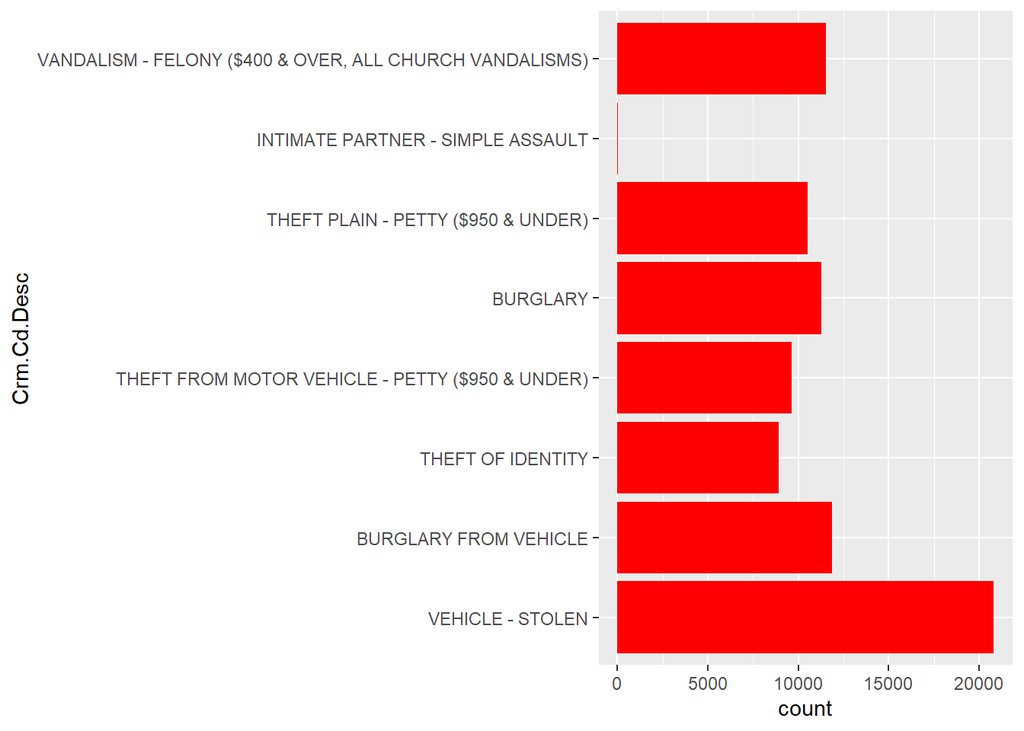

```r
filter(crimes2, `Weapon.Desc`=="") %>%
ggplot( aes(y=`Crm.Cd.Desc`)) +
  geom_bar(fill = "Red")
```

```r
df <- crimes %>% group_by(`Crm.Cd.Desc`) %>%
  count(`Weapon.Desc`) %>% arrange() %>% filter(`n` == max(`n`))

df
```

```
## # A tibble: 20 × 3
## # Groups:   Crm.Cd.Desc [20]
##    Crm.Cd.Desc                                              Weapon.Desc        n
##    <fct>                                                    <fct>          <int>
##  1 VEHICLE - STOLEN                                         ""             20815
##  2 BURGLARY FROM VEHICLE                                    ""             11860
##  3 THEFT OF IDENTITY                                        ""              8908
##  4 BATTERY - SIMPLE ASSAULT                                 "STRONG-ARM (… 14691
##  5 ASSAULT WITH DEADLY WEAPON, AGGRAVATED ASSAULT           "HAND GUN"      1591
##  6 THEFT-GRAND ($950.01 & OVER)EXCPT,GUNS,FOWL,LIVESTK,PROD ""              5381
##  7 CRIMINAL THREATS - NO WEAPON DISPLAYED                   "VERBAL THREA…  3802
##  8 THEFT FROM MOTOR VEHICLE - PETTY ($950 & UNDER)          ""              9649
##  9 BURGLARY                                                 ""             11272
## 10 THEFT PLAIN - PETTY ($950 & UNDER)                       ""             10519
## 11 INTIMATE PARTNER - SIMPLE ASSAULT                        "STRONG-ARM (… 10202
## 12 THEFT FROM MOTOR VEHICLE - GRAND ($950.01 AND OVER)      ""              4737
## 13 ROBBERY                                                  "STRONG-ARM (…  3246
## 14 INTIMATE PARTNER - AGGRAVATED ASSAULT                    "STRONG-ARM (…  1706
## 15 VIOLATION OF RESTRAINING ORDER                           ""              2466
## 16 SHOPLIFTING - PETTY THEFT ($950 & UNDER)                 ""              3466
## 17 VANDALISM - FELONY ($400 & OVER, ALL CHURCH VANDALISMS)  ""             11521
## 18 BRANDISH WEAPON                                          "HAND GUN"       465
## 19 VANDALISM - MISDEAMEANOR ($399 OR UNDER)                 ""              6164
## 20 TRESPASSING                                              ""              2770
```

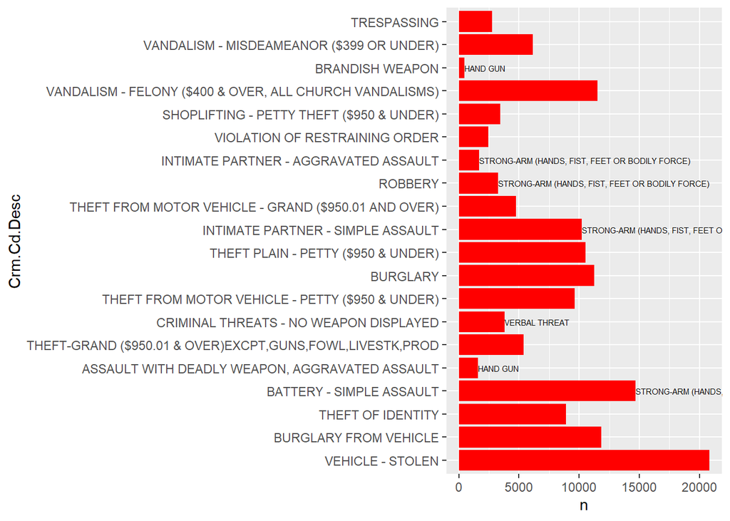

```r
ggplot(df, aes(y = `Crm.Cd.Desc`, x = `n`), text = `Weapon.Desc`) +
  geom_col(fill="Red") +
  geom_text(aes(label = `Weapon.Desc`), hjust=0, size=2)
```

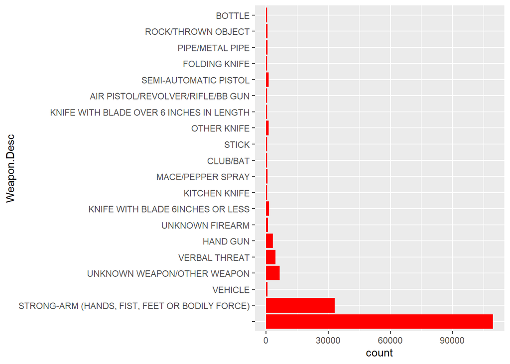

```r
toKeep <- tail(crimes %>% group_by(`Weapon.Desc`) %>% count() %>% arrange(`n`),20)
crimes <- filter(crimes, `Weapon.Desc` %in% toKeep$Weapon.Desc)
ggplot(crimes, aes(y=`Weapon.Desc`)) +
  geom_bar(fill = "Red")
```